# Time Series Analysis

2 . Structural Decomposition. First Ideas in Forecasting

Pedro Delicado. Dept. d’Estadística i Investigació Operativa, UPC

January 18th, 2023

# Structural decomposition of a time series

- Many real time series do not seem to be stationary.
  - Some of them has no constant level: They have a **trend**, that can be linear or not.
  - Some of them has a **seasonal** pattern.
- **Classical Structural Modeling**. A classical approach (50’s and 60’s of the 20th century) to time series analysis is to decompose data into components labeled **trend** ($\mu_t$), **seasonal** ($S_t$), **irregular** or **noise** ($a_t$):
  $$X_t = \mu_t + S_t + a_t.$$
- $a_t$ is usually assumed to be white noise, but it could also be a stationary time series.
- This classical approach were overcome when the ARIMA models and the Box-Jenkins methodology appeared (60’s and 70’s of the 20th century). Now both approaches are used in combination to describe and predict time series.

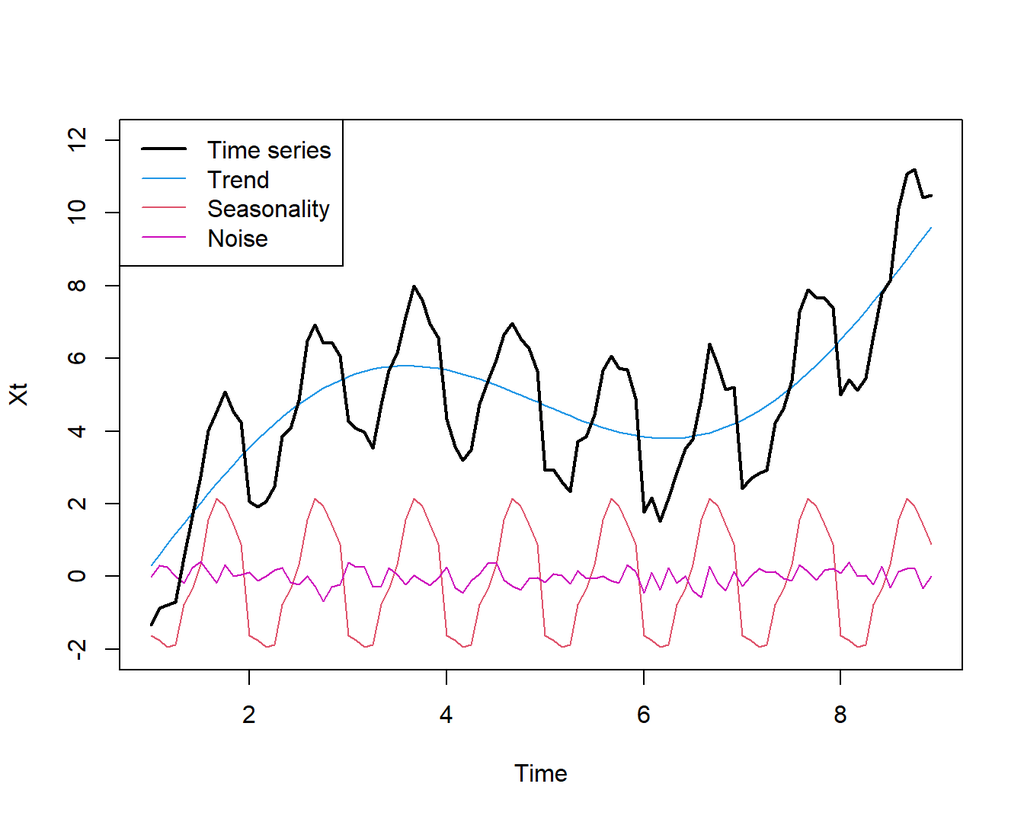

## Estimating the components of a time series

### Estimating the **trend** in $X_t=\mu_t + a_t$.

- **Deterministic trend models:**
  - A parametric model $\mu_t=f(t,\boldsymbol{\beta})$, $\boldsymbol{\beta}\in \mathbb{R}^p$ is assumed.
  - Parameter $\boldsymbol{\beta}$ is estimated by Least Squares:
    $$\min_{\boldsymbol{\beta}} \sum_{t=1}^T
    (X_t-f(t,\boldsymbol{\beta}))^2.$$
  - For instance, a **linear trend** is modeled as $f(t,\beta_0,\beta_1)=\beta_0 + \beta_1 t$, with $\beta_0$ and $\beta_1$ in $\mathbb{R}$, and it is estimated as a simple regression of $X_t$ as a function of $t$:
    $$\min_{\beta_0,\beta_1} \sum_{t=1}^T (X_t - \beta_0 - \beta_1 t)^2.$$
- **Exponential smoothing:**
  - The estimated level at time $t$ is a weighted average of past observations, where weights are decreasing exponentially with time:
    $$\hat{\mu}_{t} = (1-\alpha) \sum_{k\ge 0} \alpha^k X_{t-1-k},
    \, |\alpha|<1.$$
  - Observe that $\sum_{k\ge 0} \alpha^k= \frac{1}{1-\alpha}$ when $|\alpha|<1$.
  - Parameter $\alpha$ is estimated by Least Squares:
    $$\min_{\alpha\in(-1,1)} \sum_{t=1}^T
    \left(X_t- \frac{1-\alpha}{1-\alpha^t}
    \sum_{k=0}^{t-1} \alpha^k X_{t-1-k}
    \right)^2.$$
  - Observe that $\sum_{k=0}^{t-1} \alpha^k= \frac{1-\alpha^t}{1-\alpha}$ for all $\alpha$.
- Observe that
  $$\hat{\mu}_{t+1}
  = (1-\alpha) \sum_{k\ge 0} \alpha^k X_{t-k}$$
  $$= (1-\alpha)X_t + \alpha (1-\alpha)\sum_{k\ge 0} \alpha^k X_{t-1-k}$$
  $$= (1-\alpha)X_t + \alpha \hat{\mu}_t
  = X_t - \alpha(X_t-\hat{\mu}_t)$$
  $$\Rightarrow (X_{t+1} -\hat{\mu}_{t+1})= (X_{t+1} - X_t) +
  \alpha (X_t-\hat{\mu}_t)$$
  $$\Rightarrow X_{t+1} = X_t + \hat{w}_{t+1} - \alpha \hat{w}_t$$
- This is the estimated version of a Random Walk with a stationary noise that is not white noise: $a_t=w_t - \alpha w_{t-1}$, $w_t$ being white noise: $X_{t+1} = X_t + w_{t+1} - \alpha w_t$.
- Exponential smoothing is optimal for these models.

## Exponential smoothing. Exemple: Difference of Live Births in Spain.

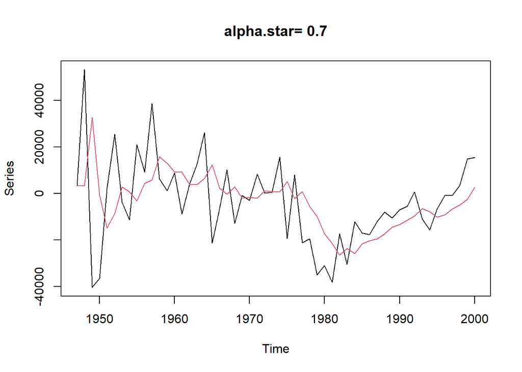

```r
library(astsa)
mu.t <- HoltWinters(diff(live.births.ts),
                    beta=FALSE,gamma=FALSE)
print(mu.t) # our alpha is denoted by (1-alpha) here!
```

```
## Holt-Winters exponential smoothing without trend and without seasonal component.
##
## Call:
## HoltWinters(x = diff(live.births.ts), beta = FALSE, gamma = FALSE)
##
## Smoothing parameters:
##  alpha: 0.210698
##  beta : FALSE
##  gamma: FALSE
##
## Coefficients:
##       [,1]
## a 3073.193
```

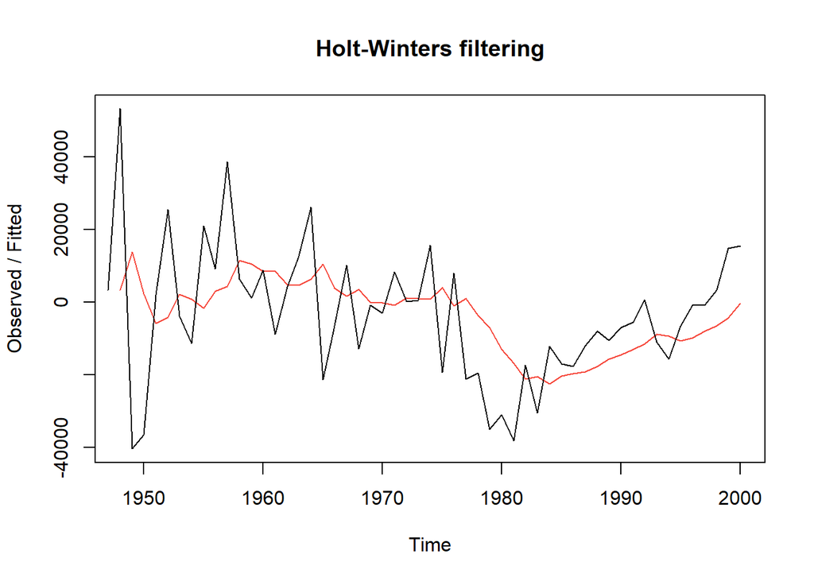

```r
plot(mu.t)
```

## Nonparametric smoothing

- **Moving averages:** $\hat{\mu}_t = \frac{1}{2k+1} \sum_{j=-k}^k X_{t+j}$.
  - $k$ is a tuning parameter to be chosen by, for example, leave-one-out cross-validation.
- **Kernel smoothing:** Let $K(u)$ be the standard Gaussian density function, and $b>0$,
  $$\hat{\mu}_t^b =
  \frac{\sum_{j=-\infty}^{\infty} K(j/b) X_{t+j}}
  {\sum_{j=-\infty}^{\infty} K(j/b)}.$$
  $\hat{\mu}_t^b$ is a weighted average of neighbor observations.
  - $b$ is a tuning parameter to be chosen by, for example, leave-one-out cross-validation.
- Sophistications:
  - Fitting a local linear regression model around $t$, depending on $(t+k)$, $k$ around $0$.
  - Fitting a local linear regression model around $t$, depending only on the past observations.

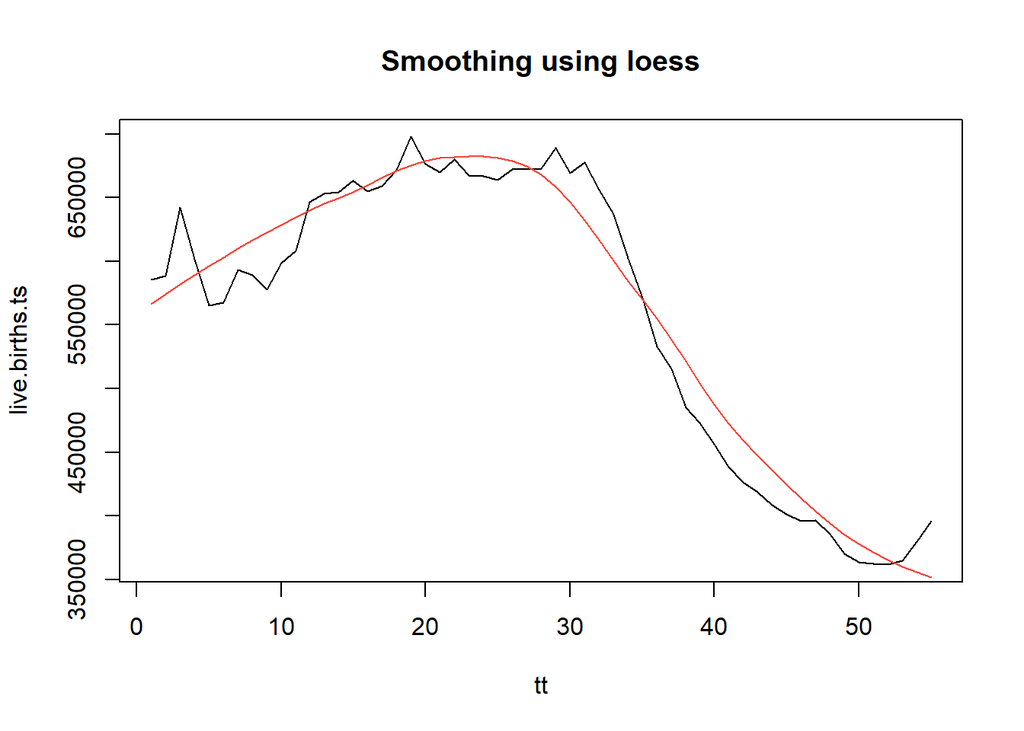

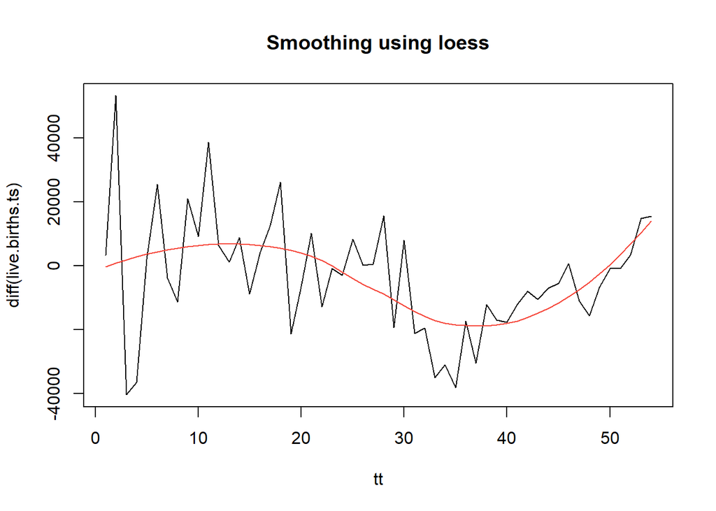

## Estimation of the seasonal component (monthly frequency)

- Estimate the trend with one of the methods described before and define $E_t = X_t - \hat{\mu}_t$.
- For each month $j=1,\ldots,12$, the seasonal component is estimated as
  $$\hat{S}_j= \bar{E}_j - \bar{E},$$
  where $\bar{E}_j$ is the average of all the the values $E_t$ corresponding to month $j$ (that is, $t=12i+j\,$), and $\bar{E}$ is the average of all the values $E_t$.
- For time $t=12i+j$, $\hat{S}_t=\hat{S}_j$.
- The irregular component $a_t$ is estimated as
  $$\hat{a}_{t}=E_{t}-\hat{S}_t.$$
- Then $X_t=\hat{\mu}_t + \hat{S}_t + \hat{a}_{t}$.

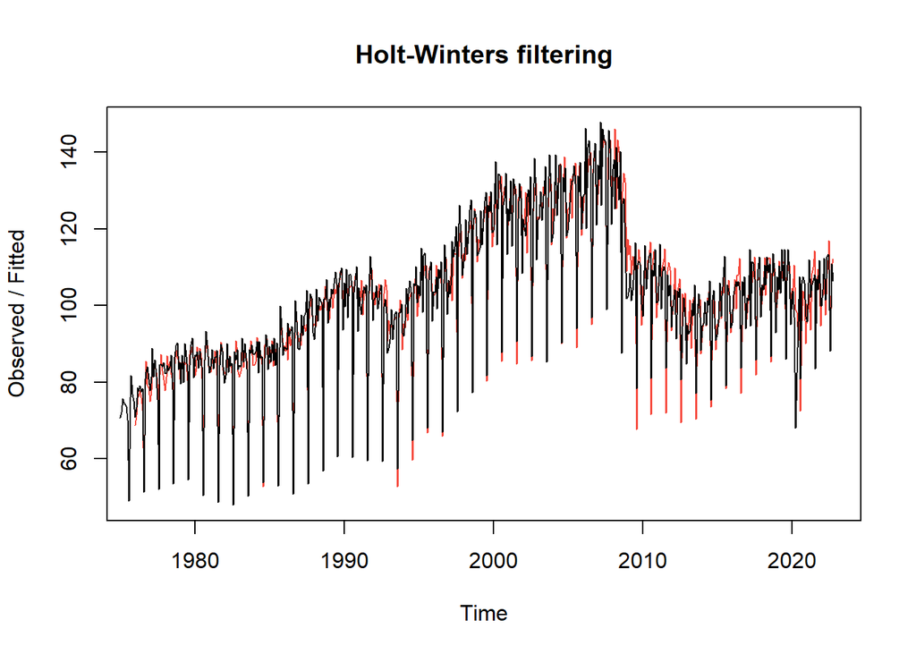

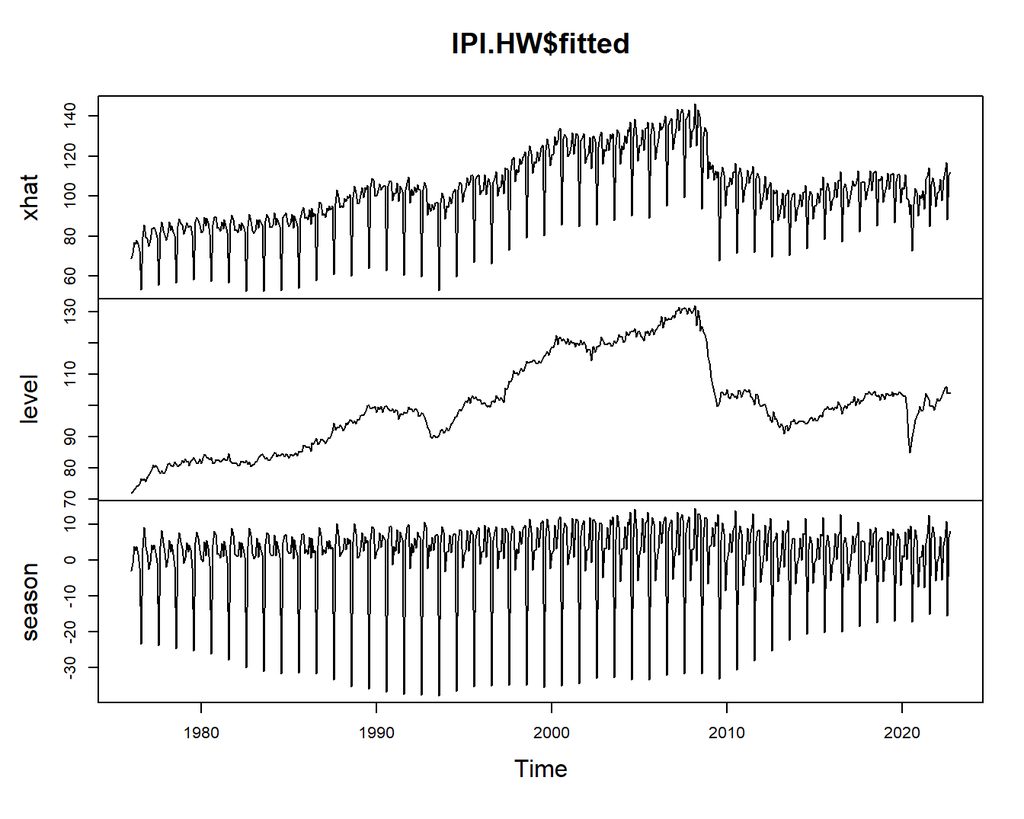

- Other functions allowing to decompose a time series into its seasonal, trend and noise components are `decompose()` and `stl()`, from the default library `stats`.
- In the case of `decompose()` decomposition is carried out by means of an adjustment of moving averages (a symmetric window with equal weights is used).
- `stl()` performs the decomposition by means of a local polynomial adjustment using the function `loess`.

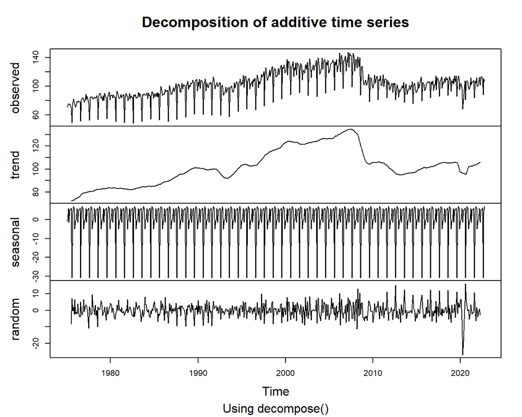

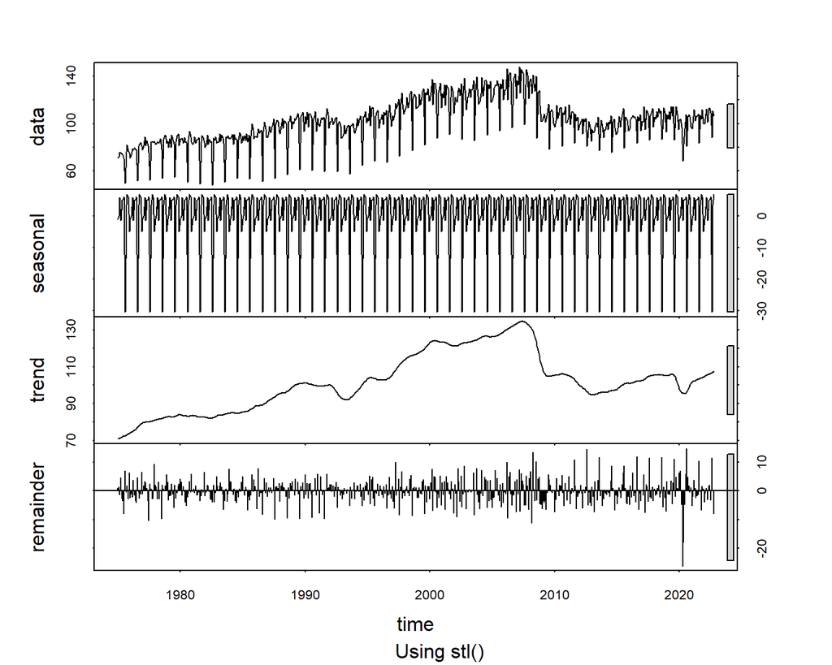

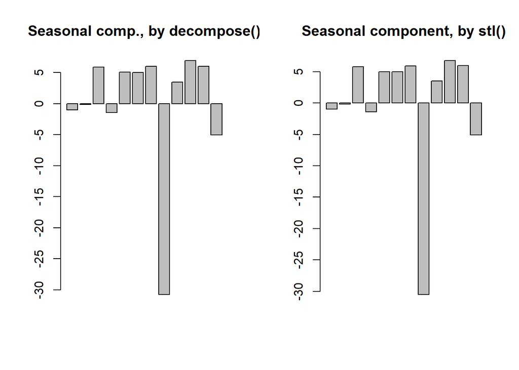

# Forecasting: First ideas

## Forecasting: First ideas

- Let $X_1,\ldots,X_T, X_{T+1}, \ldots X_{T+k}$ be the $(T+k)$ random variables that conform a time series with values at $(T+k)$ consecutive times.
- Assume that the series is observed from time $t=1$ to time $t=T$, so we assume that $X_1,\ldots,X_T$ are known values.
- **Forecasting 1 step ahead:** We want to predict (or forecast) the value of the time series *tomorrow*, that is at time $T+1$. Which value should we forecast for $X_{T+1}$?
- **Forecasting $k$ step ahead:** We want to predict (or forecast) the value of the time series at time $T+k$ from instant $T$. Which value should we forecast for $X_{T+k}$?

## Forecasting 1 step ahead

- Let $a$ be a potential forecast for the random variable $X_{T+1}$, conditional on our knowledge until time $T$, that is, $X_1,\ldots,X_T$.
- We evaluate the forecasting ability of $a$ by the **Mean Square Prediction Error (MSPE)** conditional to $X_1,\ldots,X_T$, defined as
  $$\text{MSPE}_{X_{T+1|T}}(a) = E[(X_{T+1}-a)^2|X_1,\ldots,X_T].$$
- It is easy to prove that the value $a$ minimizing $\text{MSPE}_{X_{T+1}}(a)$ is the conditional expectation of $X_{T+1}$, given $X_1,\ldots,X_T$:
  $$\hat{X}_{T+1|T}= E[X_{T+1}|X_1,\ldots,X_T].$$

## Forecasting $k$ steps ahead

- Forecasting $1$ steps ahead: $\hat{X}_{T+1|T}= E[X_{T+1}|X_1,\ldots,X_T]$.
- Forecasting $k$ steps ahead: $\hat{X}_{T+k|T}= E[X_{T+k}|X_1,\ldots,X_T]$, $k\ge 1$.
- The computation of these conditional expectations requires a previous modelization of the joint distribution of $(X_1,\ldots,X_T,X_{T+1},\ldots,X_{T+k})$.
- ARIMA models are an effective way to model it.
- We will study these models later.

### Forecasting based on a naive rule

- *Naive forecasting: Last observed value,* $\hat{X}_{T+k|T}=X_T$, $k\ge 1$.
- IPI annual rate of growth: IPI.arg$_t$= 100(IPI$_t$ - IPI$_{t-12}$)/IPI$_{t-12}$.

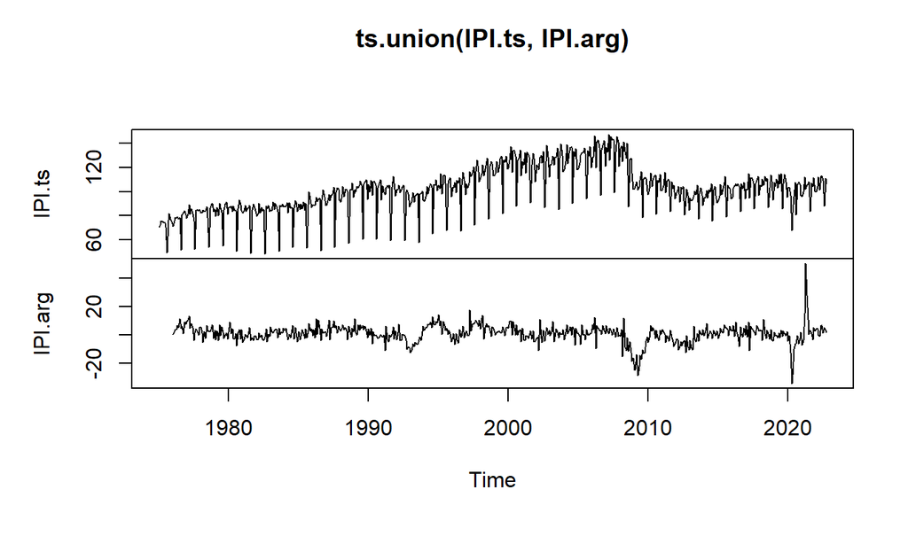

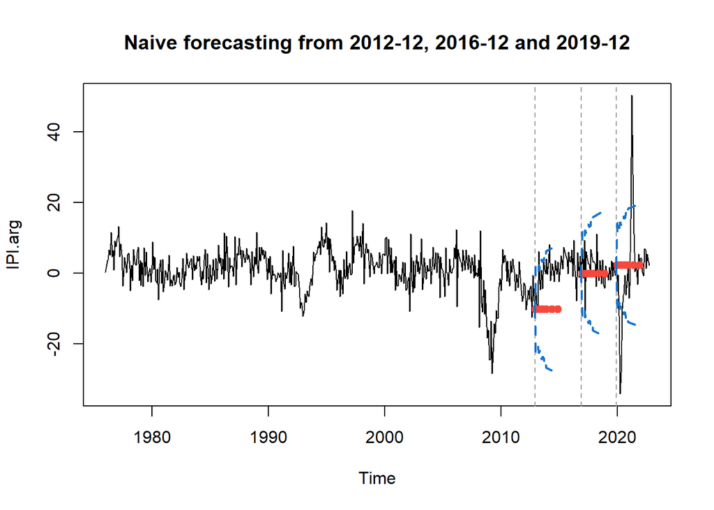

Forecasting 95% confidence interval:
$$(\hat{X}_{T+k|T} \mp 2 \widehat{\text{Std.error}}(\hat{X}_{T+k|T}))$$

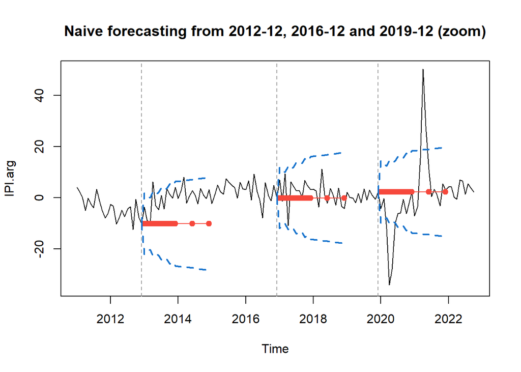

$$\widehat{\text{Std.error}}(\hat{X}_{T+k|T})=\sqrt{
\frac{1}{T-k} \sum_{t=1}^{T-k} (\hat{X}_{t+k|t} - X_{t+k})^2}$$

## Forecasting based on structural decomposition

- For the moment, assume that we have decomposed (additively) the time series $X_t$ in its structural components:
  $$X_t = \hat{\mu}_t + \hat{S}_t + \hat{a}_t, \, t=1,\ldots,T.$$
- Then the prediction $k$ steps ahead should be
  $$\hat{X}_{T+k|T} = \hat{\mu}_{T+k|T} + \hat{S}_{T+k|T} + \hat{a}_{T+k|T},$$
  where $\hat{\mu}_{T+k|T}$, $\hat{S}_{T+k|T}$ and $\hat{a}_{T+k|T}$ are, respectively, the predictions of the level, the seasonal component, and the irregular component for time $T+k$ done at time $T$.
- $\hat{X}_{T+k|T} = \hat{\mu}_{T+k|T} + \hat{S}_{T+k|T} + \hat{a}_{T+k|T}$.
- For monthly data, $\hat{S}_{T+k|T}= \hat{S}_j$ if $T+k=12 i + j$.
- If the irregular component $a_t$ is white noise, then $\hat{a}_{T+k|T}=E(a_{T+k})=0$.
- If $a_t$ is stationary, we can use ARMA models to compute $\hat{a}_{T+k|T}$ (we will see that later).

### Prediction of the level component $\hat{\mu}_{T+k|T}$

- When the level has been estimated by a parametric model, $\hat{\mu}_t=f(t,\boldsymbol{\hat{\beta}})$,
  $$\hat{\mu}_{T+k|T}=f(T+k,\boldsymbol{\hat{\beta}}).$$
  Observe that the estimation $\boldsymbol{\hat{\beta}}$ for the parameter $\boldsymbol{\beta}$ has been computed from the available data $X_1,\ldots,X_T$.

### Prediction of the level component $\hat{\mu}_{T+k|T}$

- When the level has been estimated by moving averages (`decompose()`) or by a non-parametric regression (`stl()`, that uses `loess`):
  - These procedures must be extrapolated outside the range $[1,T]$ which the predictor variable $t$ in pairs $(t,X_t)$, $t=1,\ldots,T$, belongs to.
  - Extrapolation is usually dangerous!

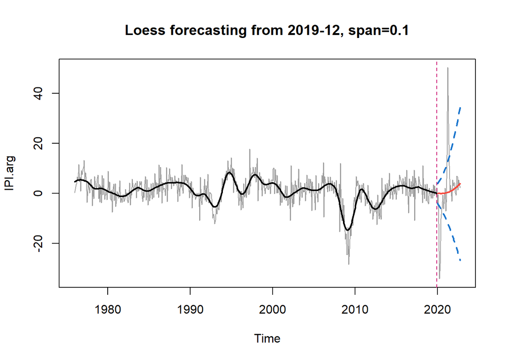

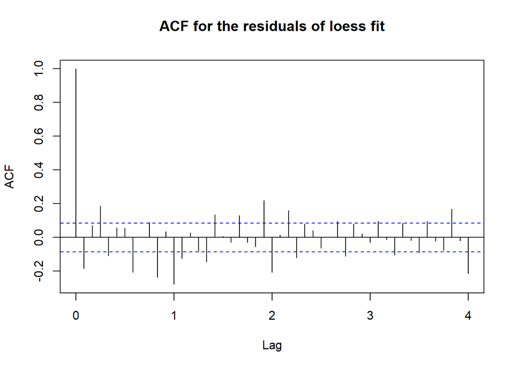

### Prediction of the level component $\hat{\mu}_{T+k|T}$

- When *exponential smoothing* has been used.
- Remember that $\hat{\mu}_{t+1} = (1-\alpha) \sum_{k\ge 0} \alpha^k X_{t-k} = X_t - \alpha(X_t-\hat{\mu}_t)$.
- Using $X_1,\ldots,X_T$, parameter $\alpha$ is estimated by least squares. The values $\hat{\mu}_t$, $t\le T$, are also estimated.
- *Forecasting:* (assuming that $a_t$ is white noise)
  - $\hat{\mu}_{T+1|T} = X_T - \hat{\alpha}(X_T-\hat{\mu}_T)$
  - $\hat{X}_{T+1|T} = \hat{\mu}_{T+1|T} + \hat{S}_{T+1|T}$
  - $\hat{\mu}_{T+2|T} = \hat{X}_{T+1|T} - \hat{\alpha}(\hat{X}_{T+1|T}-\hat{\mu}_{T+1|T})$
  - $\hat{X}_{T+2|T} = \hat{\mu}_{T+2|T} + \hat{S}_{T+2|T}$
  - $\cdots$

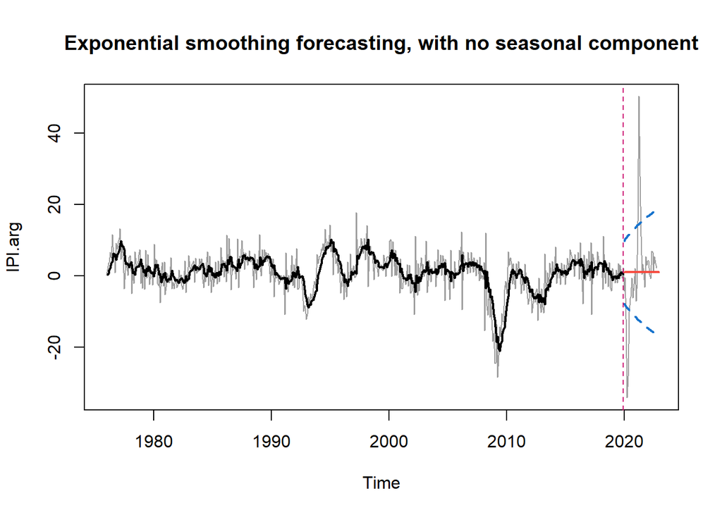

Using directly the function `plot.HoltWinters`

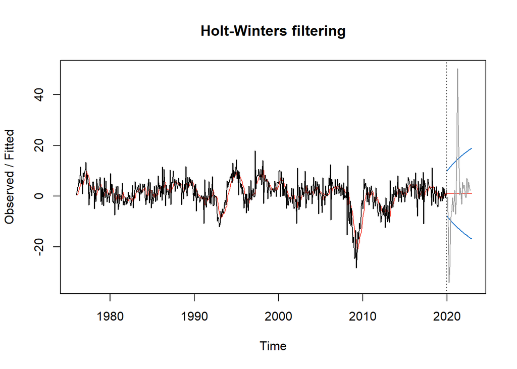

Using function `forecast.HoltWinters`, from package `forecast`.

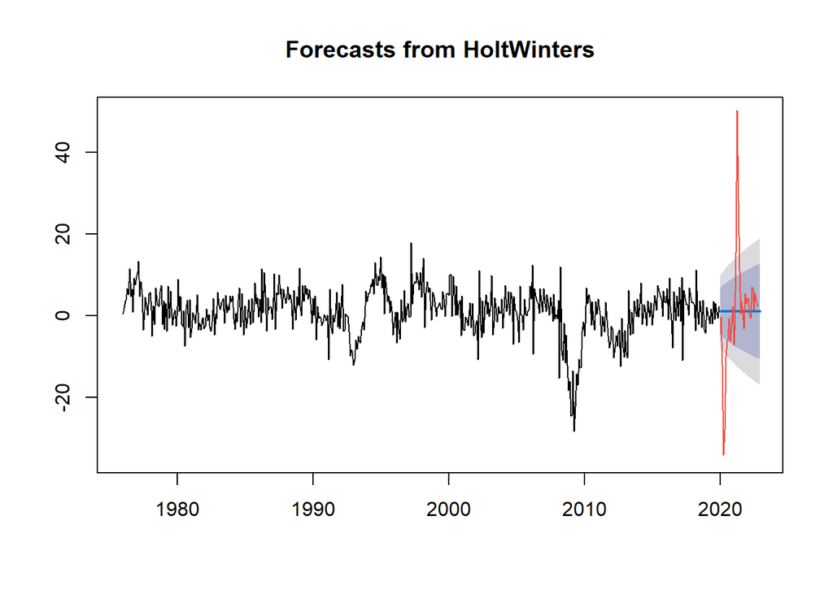

The 80% confidence band for predictions is ploted (dark grey), in addition to the usual 95% confidence band (light grey).